# Lab6 Gene Expression

#### Gene Expression and Data Visualization

#### October 23rd, 2025

## Lab6

In this lab, we will be working with an Affymetrix data set that was run on the human HGU95A array. This experiment was designed to assess the gene expression events in the frontal cortex due to aging. A total of 18 male and 12 female postmortem brain samples were obtained to assess this.

The analysis that we are interested in conducting is a direct follow up to the previous lab of differential expression. We first want to identify those genes/probes that are differentially expressed in the frontal cortex between old and young subjects, then between males and females. Next, we would like to evaluate the differences between a couple of multiple testing adjustment methods. As explained in the lecture and the course website, multiple testing is a necessary step to reduce false positives when conducting more than a single statistical test. You will generate some p-value plots to get an idea of the how conservative some methods are compared to others.

I have identified 2 gene vectors for you to use below, so do not calculate the t-test or adjustments on the entire array of genes/probes.

For the second part of this lab, you will be working with RNA-sequencing data from The Cancer Genome Atlas (TCGA), specifically a breast invasive carcinoma dataset of 119 patient tumors. The data matrix and annotation files are on the course website. We will be trying to confirm an observation from a meta-analysis performed by Mehra et al, 2005 in Cancer Research. The authors identified the gene (using arrays) and protein (using immunohistochemistry) GATA3 as a prognostic factor in breast cancer, where patients with low expression of GATA3 experienced overall worse survival. The PubMed abstract is here: http://www.ncbi.nlm.nih.gov/pubmed/16357129.

## Q1) Download the GEO Brain Aging study from the class website. Also obtain the annotation file for this data frame.

## Q2) Load into R, using read.table() function and the header=T/row.names=1 arguments for each data file.

```r
## Q1–Q2
library(DT)


# Gender-associated probes
g.g <- c(1394,1474,1917,2099,2367,2428,2625,3168,3181,3641,3832,4526,4731,
         4863,6062,6356,6684,6787,6900,7223,7244,7299,8086,8652,8959,9073,
         9145,9389,10219,11238,11669,11674,11793)

# Age-associated probes
g.a <- c(25,302,1847,2324,246,2757,3222,3675,4429,4430,4912,5640,5835,
         5856,6803,7229,7833,8133,8579,8822,8994,10101,11433,12039,12353,
         12404,12442,67,88,100)

affy_expr <- read.table("agingStudy11FCortexAffy.txt",
                        header = TRUE, row.names = 1, sep = "\t")

affy_anno <- read.table("agingStudy1FCortexAffyAnn.txt",
                        header = TRUE, sep = "\t")



dim(affy_expr)
```

```
[1] 12625    30
```

```r
head(affy_expr[, 1:5])
```

```
           GSM27015.26.M GSM27016.26.M GSM27018.29.M GSM27021.37.M
31307_at        179.8630      106.4950      265.5860      301.2430
31308_at        559.0780      411.4830      481.1760      570.7330
31309_r_at       20.7697       30.6415       50.2153       42.6892
31310_at        154.1910      224.4460      188.8230      177.8630
31311_at        956.7970      648.3100      933.6560     1016.4100
31312_at        186.5800      150.0220      262.3690      203.9770
           GSM27023.40.M
31307_at        218.5090
31308_at        333.5390
31309_r_at       27.1059
31310_at        233.4630
31311_at        762.0130
31312_at        169.4220
```

```r
head(affy_anno)
```

```
        ID Gender Age
1 GSM27015      M  26
2 GSM27016      M  26
3 GSM27018      M  29
4 GSM27021      M  37
5 GSM27023      M  40
6 GSM27024      M  42
```

## Q3) Prepare 2 separate vectors for comparison. The first is a comparison between male and female patients. The current data frame can be left alone for this, since the males and females are all grouped together. The second vector is comparison between patients >= 50 years of age and those < 50 years of age. To do this, you must use the annotation file and logical operators to isolate the correct arrays/samples.

```r
## Q3) Comparison vectors (M vs F) and (>=50 vs <50)

# 1) Extract GSM IDs from expression column names (drop ".age.sex")
expr_ids_full <- colnames(affy_expr)
expr_ids_gsm  <- sub("\\..*$", "", expr_ids_full)  # "GSM27015" from "GSM27015.26.M"

# 2) Align annotation to expression columns by GSM ID
affy_anno <- affy_anno[match(expr_ids_gsm, affy_anno$ID), ]
stopifnot(identical(affy_anno$ID, expr_ids_gsm))

# 3) Build groups
sex_fac <- factor(affy_anno$Gender, levels = c("M","F"))
age_num <- as.numeric(affy_anno$Age)
age_fac <- factor(ifelse(age_num >= 50, ">=50", "<50"), levels = c("<50", ">=50"))

idx_male   <- which(sex_fac == "M")
idx_female <- which(sex_fac == "F")
idx_lt50   <- which(age_fac == "<50")
idx_ge50   <- which(age_fac == ">=50")

wrap_html <- function(v) sprintf("<div style='white-space:normal;'>%s</div>", paste(v, collapse = ", "))

# --- Sex table ---
sex_tbl <- data.frame(
  Group   = c("M", "F"),
  Qty     = c(length(idx_male), length(idx_female)),
  Samples = c(wrap_html(expr_ids_full[idx_male]),
              wrap_html(expr_ids_full[idx_female])),
  stringsAsFactors = FALSE
)

# --- Age table ---
age_tbl <- data.frame(
  Group   = c("<50", ">=50"),
  Qty     = c(length(idx_lt50), length(idx_ge50)),
  Samples = c(wrap_html(expr_ids_full[idx_lt50]),
              wrap_html(expr_ids_full[idx_ge50])),
  stringsAsFactors = FALSE
)

# --- Render clean tables ---
datatable(
  sex_tbl, rownames = FALSE, escape = FALSE,
  options = list(paging = FALSE, dom = 't', scrollX = TRUE)
)
```

| Group | Qty | Samples |
| --- | --- | --- |
| M | 18 | GSM27015.26.M, GSM27016.26.M, GSM27018.29.M, GSM27021.37.M, GSM27023.40.M, GSM27024.42.M, GSM27025.45.M, GSM27027.52.M, GSM27028.53.M, GSM27031.66.M, GSM27032.70.M, GSM27034.73.M, GSM27035.77.M, GSM27… |
| F | 12 | GSM27017.27.F, GSM27019.30.F, GSM27020.36.F, GSM27022.38.F, GSM27026.48.F, GSM27029.56.F, GSM27030.61.F, GSM27033.71.F, GSM27037.81.F, GSM27039.87.F, GSM27041.90.F, GSM27044.106.F |

```r
datatable(
  age_tbl, rownames = FALSE, escape = FALSE,
  options = list(paging = FALSE, dom = 't', scrollX = TRUE)
)
```

| Group | Qty | Samples |
| --- | --- | --- |
| <50 | 12 | GSM27015.26.M, GSM27016.26.M, GSM27018.29.M, GSM27021.37.M, GSM27023.40.M, GSM27024.42.M, GSM27025.45.M, GSM27017.27.F, GSM27019.30.F, GSM27020.36.F, GSM27022.38.F, GSM27026.48.F |
| >=50 | 18 | GSM27027.52.M, GSM27028.53.M, GSM27031.66.M, GSM27032.70.M, GSM27034.73.M, GSM27035.77.M, GSM27036.80.M, GSM27038.85.M, GSM27040.90.M, GSM27042.91.M, GSM27043.95.M, GSM27029.56.F, GSM27030.61.F, GSM27… |

## Q4) Run the t.test function from the notes using the first gene vector below for the gender comparison. Then use the second gene vector below for the age comparison. Using these p-values, use either p.adjust in the base library or mt.rawp2adjp in the multtest library to adjust the values for multiple corrections with the Holm’s method.

```r
## Q4) t-tests and Holm’s correction
# Function to run unpaired equal-variance t-tests for a set of probes
run_ttests <- function(expr, probe_idx, group_factor) {
  sapply(probe_idx, function(i) {
    x <- as.numeric(expr[i, ])
    t.test(x ~ group_factor, var.equal = TRUE)$p.value
  })
}

# --- (a) Gender comparison ---
p_gender <- run_ttests(affy_expr, g.g, sex_fac)
p_gender_holm <- p.adjust(p_gender, method = "holm")

# Combine into a results data frame
res_gender <- data.frame(
  Probe = rownames(affy_expr)[g.g],
  Raw_p  = signif(p_gender, 4),
  Holm_p = signif(p_gender_holm, 4)
)

# --- (b) Age comparison ---
p_age <- run_ttests(affy_expr, g.a, age_fac)
p_age_holm <- p.adjust(p_age, method = "holm")

res_age <- data.frame(
  Probe = rownames(affy_expr)[g.a],
  Raw_p  = signif(p_age, 4),
  Holm_p = signif(p_age_holm, 4)
)
datatable(
  res_gender, rownames = FALSE,
  caption = "Q4a. Gender comparison: raw and Holm-adjusted p-values",
  options = list(paging = FALSE, dom = 't')
)
```

| Probe | Raw_p | Holm_p |
| --- | --- | --- |
| 35570_at | 0.009133 | 0.09613 |
| 36367_at | 7.329e-05 | 0.001832 |
| 33937_at | 0.007743 | 0.09613 |
| 34477_at | 1.173e-10 | 3.753e-09 |
| 35465_at | 0.00143 | 0.03289 |
| 35885_at | 4.843e-09 | 1.453e-07 |
| 36321_at | 6.369e-07 | 1.656e-05 |
| 38182_at | 0.004203 | 0.07565 |
| 38195_at | 0.009129 | 0.09613 |
| 39613_at | 0.003275 | 0.07205 |

[output cut: 23 more lines]

```r
datatable(
  res_age, rownames = FALSE,
  caption = "Q4b. Age comparison: raw and Holm-adjusted p-values",
  options = list(paging = FALSE, dom = 't')
)
```

| Probe | Raw_p | Holm_p |
| --- | --- | --- |
| 31331_at | 0.1889 | 0.9444 |
| 31608_g_at | 2.324e-05 | 0.0005346 |
| 33508_at | 2.01e-05 | 0.0004823 |
| 35422_at | 6.329e-05 | 0.0006961 |
| 31552_at | 0.8325 | 1 |
| 37053_at | 2.362e-05 | 0.0005346 |
| 38236_at | 1.12e-05 | 0.0003249 |
| 39647_s_at | 4.043e-05 | 0.0006331 |
| 41719_i_at | 3.957e-05 | 0.0006331 |
| 41720_r_at | 1.194e-05 | 0.0003344 |

[output cut: 20 more lines]

## Q5) Sort the adjusted p-values and non-adjusted p-values and plot them vs. the x-axis of numbers for each comparison data set. Make sure that the two lines are different colors. Also make sure that the p-values are sorted before plotting.

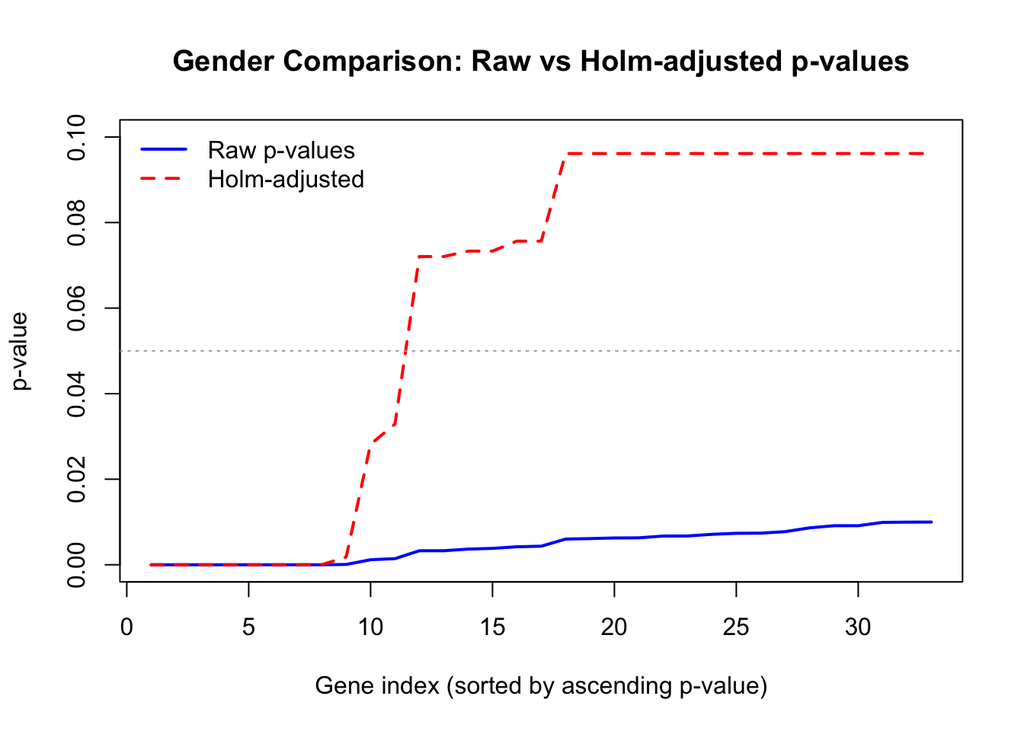

```r
## Q5) Sorted p-values: raw vs Holm-adjusted

# --- Gender comparison ---
ord_gender_raw  <- sort(p_gender)
ord_gender_holm <- sort(p_gender_holm)
n_gender <- length(ord_gender_raw)

plot(1:n_gender, ord_gender_raw, type = "l", col = "blue", lwd = 2,
     xlab = "Gene index (sorted by ascending p-value)",
     ylab = "p-value",
     ylim = c(0,0.1),
     main = "Gender Comparison: Raw vs Holm-adjusted p-values")
lines(1:n_gender, ord_gender_holm, col = "red", lwd = 2, lty = 2)
abline(h = 0.05, col = "darkgray", lty = 3)
legend("topleft", legend = c("Raw p-values", "Holm-adjusted"),
       col = c("blue", "red"), lwd = 2, lty = c(1,2), bty = "n")
```

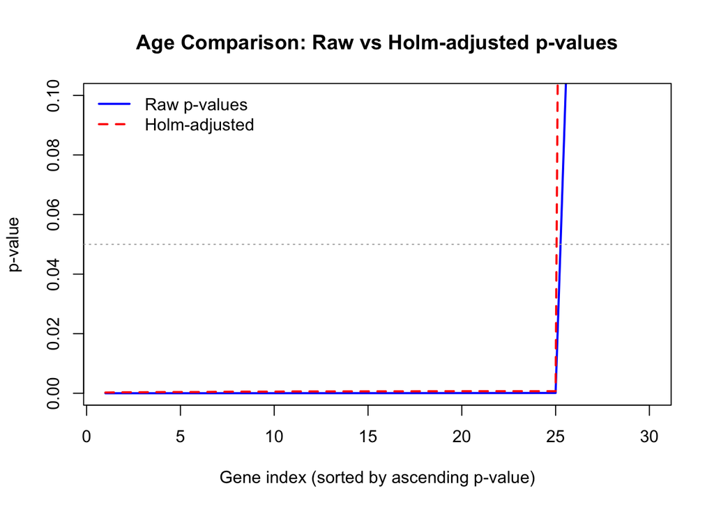

```r
# --- Age comparison ---
ord_age_raw  <- sort(p_age)
ord_age_holm <- sort(p_age_holm)
n_age <- length(ord_age_raw)

plot(1:n_age, ord_age_raw, type = "l", col = "blue", lwd = 2,
     xlab = "Gene index (sorted by ascending p-value)",
     ylab = "p-value",
     ylim = c(0,0.1),
     main = "Age Comparison: Raw vs Holm-adjusted p-values")
lines(1:n_age, ord_age_holm, col = "red", lwd = 2, lty = 2)
abline(h = 0.05, col = "darkgray", lty = 3)
legend("topleft", legend = c("Raw p-values", "Holm-adjusted"),
       col = c("blue", "red"), lwd = 2, lty = c(1,2), bty = "n")
```

## Q6) Repeat #4 and #5 with the Bonferroni method.

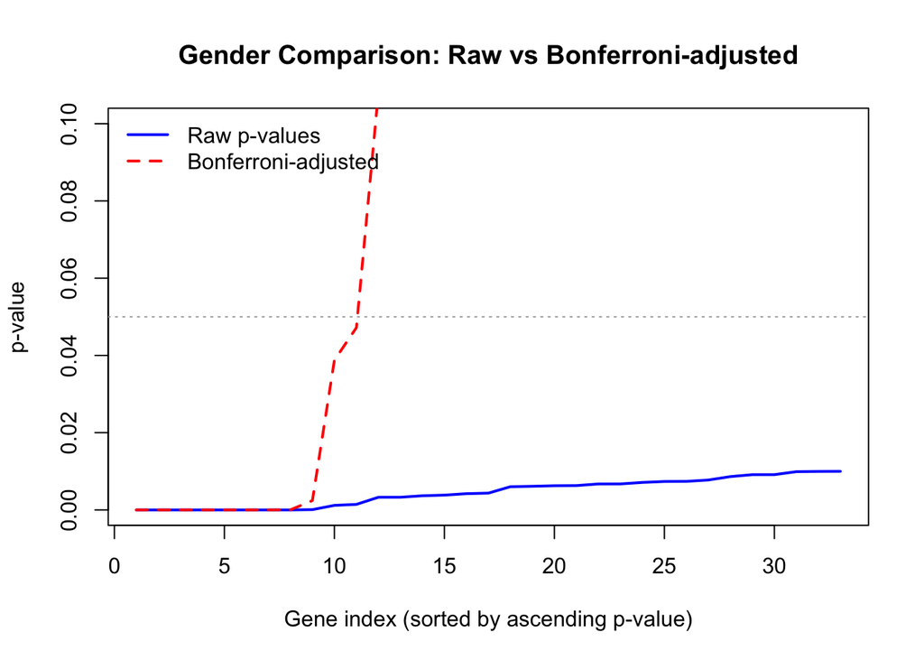

```r
## Q6) Repeat analysis using Bonferroni correction (y-axis 0–0.10)

# --- (a) Gender comparison ---
p_gender_bonf <- p.adjust(p_gender, method = "bonferroni")

# --- (b) Age comparison ---
p_age_bonf <- p.adjust(p_age, method = "bonferroni")

# --- Plot: Gender and Age (Raw vs Bonferroni) ---

# Gender
ord_gender_raw  <- sort(p_gender)
ord_gender_bonf <- sort(p_gender_bonf)
n_gender <- length(ord_gender_raw)

plot(1:n_gender, ord_gender_raw, type = "l", col = "blue", lwd = 2,
     ylim = c(0, 0.10),
     xlab = "Gene index (sorted by ascending p-value)",
     ylab = "p-value",
     main = "Gender Comparison: Raw vs Bonferroni-adjusted")
lines(1:n_gender, ord_gender_bonf, col = "red", lwd = 2, lty = 2)
abline(h = 0.05, col = "darkgray", lty = 3)
legend("topleft", legend = c("Raw p-values", "Bonferroni-adjusted"),
       col = c("blue", "red"), lwd = 2, lty = c(1,2), bty = "n")
```

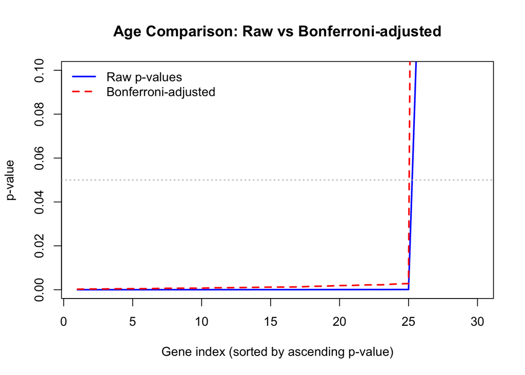

```r
# Age
ord_age_raw  <- sort(p_age)
ord_age_bonf <- sort(p_age_bonf)
n_age <- length(ord_age_raw)

plot(1:n_age, ord_age_raw, type = "l", col = "blue", lwd = 2,
     ylim = c(0, 0.10),
     xlab = "Gene index (sorted by ascending p-value)",
     ylab = "p-value",
     main = "Age Comparison: Raw vs Bonferroni-adjusted")
lines(1:n_age, ord_age_bonf, col = "red", lwd = 2, lty = 2)
abline(h = 0.05, col = "darkgray", lty = 3)
legend("topleft", legend = c("Raw p-values", "Bonferroni-adjusted"),
       col = c("blue", "red"), lwd = 2, lty = c(1,2), bty = "n")
```

```r
# Threshold for significance
alpha <- 0.05

# --- Gender comparison ---
sig_gender_idx <- which(p_gender_bonf < alpha)
sig_gender_tbl <- data.frame(
  Probe_ID = rownames(affy_expr)[g.g[sig_gender_idx]],
  Raw_p    = p_gender[sig_gender_idx],
  Bonf_p   = p_gender_bonf[sig_gender_idx],
  stringsAsFactors = FALSE
)

# Sort from smallest to largest adjusted p-value
sig_gender_tbl <- sig_gender_tbl[order(sig_gender_tbl$Bonf_p), ]
sig_gender_tbl$Raw_p  <- signif(sig_gender_tbl$Raw_p, 4)
sig_gender_tbl$Bonf_p <- signif(sig_gender_tbl$Bonf_p, 4)

# --- Age comparison ---
sig_age_idx <- which(p_age_bonf < alpha)
sig_age_tbl <- data.frame(
  Probe_ID = rownames(affy_expr)[g.a[sig_age_idx]],
  Raw_p    = p_age[sig_age_idx],
  Bonf_p   = p_age_bonf[sig_age_idx],
  stringsAsFactors = FALSE
)

sig_age_tbl <- sig_age_tbl[order(sig_age_tbl$Bonf_p), ]
sig_age_tbl$Raw_p  <- signif(sig_age_tbl$Raw_p, 4)
sig_age_tbl$Bonf_p <- signif(sig_age_tbl$Bonf_p, 4)

# --- Render DT tables (ranked smallest → largest Bonferroni p-value) ---
datatable(
  sig_gender_tbl,
  caption = "Significant probes after Bonferroni correction – Gender comparison (ranked by adjusted p-value)",
  rownames = FALSE,
  options = list(paging = FALSE, dom = 't')
)
```

| Probe_ID | Raw_p | Bonf_p |
| --- | --- | --- |
| 41214_at | 3.498e-17 | 1.154e-15 |
| 34477_at | 1.173e-10 | 3.87e-09 |
| 38446_at | 1.466e-09 | 4.838e-08 |
| 35885_at | 4.843e-09 | 1.598e-07 |
| 38355_at | 8.558e-09 | 2.824e-07 |
| 37583_at | 1.093e-08 | 3.605e-07 |
| 40097_at | 4.061e-08 | 1.34e-06 |
| 36321_at | 6.369e-07 | 2.102e-05 |
| 36367_at | 7.329e-05 | 0.002419 |
| 41138_at | 0.001175 | 0.03877 |

[output cut: 1 more lines]

```r
datatable(
  sig_age_tbl,
  caption = "Significant probes after Bonferroni correction – Age comparison (ranked by adjusted p-value)",
  rownames = FALSE,
  options = list(paging = FALSE, dom = 't')
)
```

| Probe_ID | Raw_p | Bonf_p |
| --- | --- | --- |
| 36681_at | 8.052e-06 | 0.0002416 |
| 38236_at | 1.12e-05 | 0.0003361 |
| 41720_r_at | 1.194e-05 | 0.0003583 |
| 35277_at | 1.446e-05 | 0.0004338 |
| 275_at | 1.543e-05 | 0.0004629 |
| 1217_g_at | 1.576e-05 | 0.0004728 |
| 33508_at | 2.01e-05 | 0.0006029 |
| 31608_g_at | 2.324e-05 | 0.0006973 |
| 37053_at | 2.362e-05 | 0.0007087 |
| 36897_at | 2.402e-05 | 0.0007206 |

[output cut: 15 more lines]

## Q7) Read in the log2 normalized fragments per kb per million mapped reads (FPKM) data matrix and annotation files. This is RNA-sequencing data that has normalized read counts on a similar scale to microarray intensities.

```r
## Q7) Load TCGA BRCA log2(FPKM) and align to SAM (patient-level)

# 1) Read files
tcga_expr <- read.table("tcga_brca_fpkm.txt",
                        header = TRUE, row.names = 1, sep = "\t", check.names = FALSE)
tcga_sam  <- read.table("tcga_brca_fpkm_sam.txt",
                        header = TRUE, sep = "\t", check.names = FALSE)

# 2) Standardize barcodes
expr_ids_std <- gsub("\\.", "-", colnames(tcga_expr))
expr_pat12   <- substr(expr_ids_std, 1, 12)                    # patient barcode (e.g., TCGA-FD-A3NA)

sam_ids_std  <- gsub("\\.", "-", as.character(tcga_sam$bcr_patient_barcode))
sam_pat12    <- substr(sam_ids_std, 1, 12)                     # should already be 12-char

# 3) Collapse expression to one column per patient by averaging aliquots (if any)
#    rows = genes, columns = samples -> transpose, group rows by patient, then transpose back
expr_sum  <- rowsum(t(tcga_expr), group = expr_pat12)          # sum across aliquots per patient
expr_n    <- as.vector(table(expr_pat12))                      # counts per patient (sorted like rowsum rownames)
tcga_expr_pat <- t(expr_sum / expr_n[col(expr_sum)[,1]])       # mean per patient

# Ensure column order follows the rowsum rownames (patient IDs)
stopifnot(identical(colnames(tcga_expr_pat), rownames(expr_sum)))

# 4) Align to SAM order and drop unmatched safely
match_idx <- match(sam_pat12, colnames(tcga_expr_pat))
keep <- !is.na(match_idx)

tcga_expr_pat <- tcga_expr_pat[, match_idx[keep], drop = FALSE]
tcga_sam_aln  <- tcga_sam[keep, , drop = FALSE]

# Rename columns to the patient barcode for clarity
colnames(tcga_expr_pat) <- sam_pat12[keep]

# 5) Create survival-ready fields for downstream steps
tcga_sam_aln$time   <- suppressWarnings(as.numeric(tcga_sam_aln$months_to_event))
tcga_sam_aln$status <- ifelse(toupper(tcga_sam_aln$vital_status) == "DECEASED", 1L, 0L)
```

## Q8) Use grep to subset the data matrix only by gene ‘GATA3’ and make sure to cast this vector to numeric.

```r
# Use the patient-level matrix from Q7
expr_mat <- tcga_expr_pat  # genes × patients

# 1) Locate GATA3 (case-insensitive, supports ENSG/pipe suffixes)
gata_rows <- grep("^GATA3(\\b|\\|)", rownames(expr_mat), ignore.case = TRUE)
stopifnot(length(gata_rows) >= 1)

# 2) Extract and cast to numeric
gata_mat <- expr_mat[gata_rows, , drop = FALSE]
gata3 <- if (nrow(gata_mat) == 1) as.numeric(gata_mat[1, ]) else as.numeric(colMeans(gata_mat, na.rm = TRUE))
names(gata3) <- colnames(expr_mat)

# 3) Create a tidy dataframe for display
gata_tbl <- data.frame(
  Sample_ID = names(gata3),
  GATA3_log2FPKM = signif(gata3, 4),
  stringsAsFactors = FALSE
)

# 4) Render interactive table
datatable(
  gata_tbl,
  caption = "GATA3 expression across TCGA BRCA samples (log₂ FPKM)",
  rownames = FALSE,
  options = list(pageLength = 10)
)
```

| Sample_ID | GATA3_log2FPKM |
| --- | --- |
| TCGA-FD-A3NA | 14.02 |
| TCGA-FD-A3N6 | 4.386 |
| TCGA-DK-A2I4 | 11.23 |
| TCGA-DK-A3IK | 13.59 |
| TCGA-BT-A20V | 10.27 |
| TCGA-BT-A20O | 8.096 |
| TCGA-BT-A20P | 14.12 |
| TCGA-BT-A20U | 10.45 |
| TCGA-CF-A1HR | 12.27 |
| TCGA-CF-A1HS | 9.092 |

[output cut: 109 more lines]

## Q9) Create a binary (1/0) vector for the patients where the upper 25% expression of GATA3 is coded as 1 and all other patients are coded as 0. Call this new variable ‘group’.

```r
## Q9) Create binary vector for upper 25% GATA3 expression

# 1) Ensure GATA3 vector is numeric and aligned to patient order
stopifnot(is.numeric(gata3))

# 2) Calculate the 75th percentile cutoff
gata_cut <- quantile(gata3, 0.75, na.rm = TRUE)

# 3) Define binary group: 1 = upper 25% (high expression), 0 = remaining 75%
group <- ifelse(gata3 >= gata_cut, 1L, 0L)
names(group) <- names(gata3)

# 4) Combine with expression for clarity
gata_group_tbl <- data.frame(
  Sample_ID = names(gata3),
  GATA3_log2FPKM = signif(gata3, 4),
  Group = group,
  stringsAsFactors = FALSE
)

# 5) Visualize
datatable(
  gata_group_tbl,
  caption = "Binary grouping of patients by GATA3 expression (upper 25% = 1)",
  rownames = FALSE,
)
```

| Sample_ID | GATA3_log2FPKM | Group |
| --- | --- | --- |
| TCGA-FD-A3NA | 14.02 | 1 |
| TCGA-FD-A3N6 | 4.386 | 0 |
| TCGA-DK-A2I4 | 11.23 | 0 |
| TCGA-DK-A3IK | 13.59 | 1 |
| TCGA-BT-A20V | 10.27 | 0 |
| TCGA-BT-A20O | 8.096 | 0 |
| TCGA-BT-A20P | 14.12 | 1 |
| TCGA-BT-A20U | 10.45 | 0 |
| TCGA-CF-A1HR | 12.27 | 0 |
| TCGA-CF-A1HS | 9.092 | 0 |

[output cut: 109 more lines]

## Q10) Create a data matrix with the ‘group’ variable you created in #9 and the remaining variables in the annotation file.

```r
## Q10) Merge binary GATA3 group with clinical annotation

# 1) Make sure identifiers align between GATA3 vector and SAM
expr_ids <- substr(names(gata3), 1, 12)
sam_ids  <- substr(gsub("\\.", "-", tcga_sam_aln$bcr_patient_barcode), 1, 12)

# 2) Match annotation rows to GATA3 order
match_idx <- match(expr_ids, sam_ids)

# 3) Combine into one data frame
gata_clin_df <- data.frame(
  Patient_ID = expr_ids,
  GATA3_log2FPKM = signif(gata3, 4),
  Group = group,
  tcga_sam_aln[match_idx, c(
    "age_at_initial_pathologic_diagnosis",
    "gender",
    "vital_status",
    "months_to_event",
    "time",
    "status"
  )],
  stringsAsFactors = FALSE
)

# 4) Display as a DT table
datatable(
  gata_clin_df,
  caption = "Merged TCGA BRCA annotation with GATA3 grouping (Group = 1 → high expression)",
  rownames = FALSE,
)
```

| Patient_ID | GATA3_log2FPKM | Group | age_at_initial_pathologic_diagnosis | gender | vital_status | months_to_event | time | status |
| --- | --- | --- | --- | --- | --- | --- | --- | --- |
| TCGA-FD-A3NA | 14.02 | 1 | 60 | MALE | LIVING | 32.4666666666667 | 32.4666666666667 | 0 |
| TCGA-FD-A3N6 | 4.386 | 0 | 43 | FEMALE | LIVING | 8.06666666666667 | 8.06666666666667 | 0 |
| TCGA-DK-A2I4 | 11.23 | 0 | 79 | MALE | LIVING | 125.566666666667 | 125.566666666667 | 0 |
| TCGA-DK-A3IK | 13.59 | 1 | 87 | MALE | LIVING | 2.23333333333333 | 2.23333333333333 | 0 |
| TCGA-BT-A20V | 10.27 | 0 | 59 | FEMALE | DECEASED | 5.13333333333333 | 5.13333333333333 | 1 |
| TCGA-BT-A20O | 8.096 | 0 | 75 | MALE | DECEASED | 12.3333333333333 | 12.3333333333333 | 1 |
| TCGA-BT-A20P | 14.12 | 1 | 81 | FEMALE | DECEASED | 18.1 | 18.1 | 1 |
| TCGA-BT-A20U | 10.45 | 0 | 70 | FEMALE | DECEASED | 8.73333333333333 | 8.73333333333333 | 1 |
| TCGA-CF-A1HR | 12.27 | 0 | 62 | MALE | LIVING | 0.466666666666667 | 0.466666666666667 | 0 |
| TCGA-CF-A1HS | 9.092 | 0 | 75 | FEMALE | LIVING | 0.433333333333333 | 0.433333333333333 | 0 |

[output cut: 109 more lines]

## Q11) Run a Kaplan-Meier (KM) analysis to determine if a difference in survival experience exists between the two GATA3 expression groups using the survdiff function. Extract the p-value from the chi squared test output.

```r
## Q11) Kaplan–Meier (KM) survival comparison: high vs. low GATA3 expression

library(survival)
# 1) Prepare survival object
# Ensure time and status are numeric and aligned
surv_obj <- Surv(time = gata_clin_df$time, event = gata_clin_df$status)

# 2) Run log-rank test between groups (1 = high GATA3, 0 = low)
km_test <- survdiff(surv_obj ~ gata_clin_df$Group)

# 3) Extract p-value from chi-squared statistic
chisq_val <- km_test$chisq
p_val <- 1 - pchisq(chisq_val, df = 1)

# 4) Display results
p_val_fmt <- signif(p_val, 4)
cat("Log-rank test Chi-squared =", round(chisq_val, 3),
    "with p-value =", p_val_fmt, "\n")
```

```
Log-rank test Chi-squared = 3.215 with p-value = 0.07296
```

**Result interpretation:** Although the GATA3-high group showed a modest survival advantage relative to the GATA3-low group, the difference did not reach statistical significance (χ² = 3.215, p = 0.073). This suggests a possible but inconclusive association between GATA3 expression and patient survival in the TCGA BRCA cohort.

## Q12) Now run a Cox proportion hazard (PH) regression model on just the grouping variable (i.e. no other covariates) and extract both the p-value and hazard ratio from the output.

```r
## Q12) Cox Proportional Hazards (PH) model using GATA3 group

# 1) Create survival object
surv_obj <- Surv(time = gata_clin_df$time, event = gata_clin_df$status)

# 2) Fit Cox PH model with GATA3 group as the only predictor
cox_model <- coxph(surv_obj ~ gata_clin_df$Group)

# 3) Summarize results
cox_summary <- summary(cox_model)

# 4) Extract hazard ratio (HR) and p-value
hr <- signif(cox_summary$coef[,"exp(coef)"], 4)
p_val <- signif(cox_summary$coef[,"Pr(>|z|)"], 4)

cat("Hazard Ratio (HR) =", hr, "\n")
```

```
Hazard Ratio (HR) = 0.4266
```

```r
cat("p-value =", p_val, "\n")
```

```
p-value = 0.08162
```

**Result Interpretation:** The Cox PH model (HR = 0.43, p = 0.082) indicates that higher GATA3 expression is associated with a lower hazard of death, though this relationship does not reach statistical significance. This aligns with the Kaplan–Meier result showing a similar trend toward improved survival among patients with elevated GATA3 expression.

## Q13) Run the survfit() function only on the grouping variable (i.e. no other covariates) and plot the KM curves, being sure to label the two groups with a legend, two different colors for each line, and provide the KM p-value, Cox PH p-value, Cox PH hazard ratio, and sample sizes all in each of the two groups all on the plot.

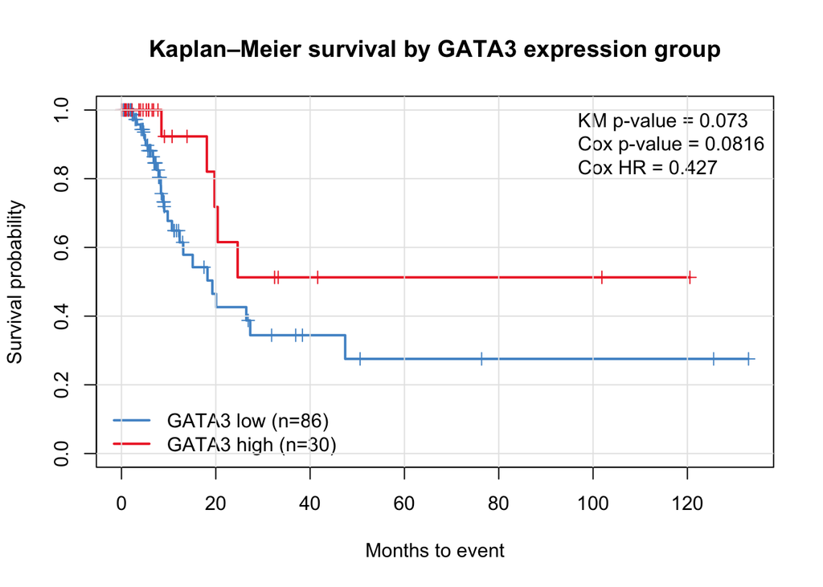

```r
## Q13) KM curves (survfit) for GATA3 groups with on-plot stats

library(survival)

# ----- data prep (complete cases only) -----
dat <- gata_clin_df
cc  <- complete.cases(dat$time, dat$status, dat$Group)
dat <- dat[cc, ]

# n per group
n0 <- sum(dat$Group == 0, na.rm = TRUE)  # low (bottom 75%)
n1 <- sum(dat$Group == 1, na.rm = TRUE)  # high (top 25%)

# ----- KM fit (no covariates) -----
fit <- survfit(Surv(time, status) ~ Group, data = dat)

# ----- KM (log-rank) p-value -----
km_test <- survdiff(Surv(time, status) ~ Group, data = dat)
km_p <- 1 - pchisq(km_test$chisq, df = 1)

# ----- Cox PH (univariate) -----
cox_mod <- coxph(Surv(time, status) ~ Group, data = dat)
cx      <- summary(cox_mod)
cox_hr  <- cx$coef[,"exp(coef)"]
cox_p   <- cx$coef[,"Pr(>|z|)"]

# ----- plot -----
cols <- c("steelblue3", "firebrick2")   # 0 = blue (low), 1 = red (high)
plot(fit,
     col = cols, lwd = 2, mark.time = TRUE, conf.int = FALSE,
     xlab = "Months to event", ylab = "Survival probability",
     main = "Kaplan–Meier survival by GATA3 expression group")

legend("bottomleft",
       legend = c(paste0("GATA3 low (n=", n0, ")"),
                  paste0("GATA3 high (n=", n1, ")")),
       col = cols, lwd = 2, bty = "n")

# stats block shown on the figure
stats_text <- c(
  paste0("KM p-value = ", signif(km_p, 3)),
  paste0("Cox p-value = ", signif(cox_p, 3)),
  paste0("Cox HR = ", signif(cox_hr, 3))
)
legend("topright", legend = stats_text, bty = "n")

# (Optional) add light grid
abline(h = seq(0, 1, by = 0.2), v = pretty(dat$time), col = "gray90", lwd = 1)
```

## Q14) Does this result agree with the Mehra et al, study result?

The present TCGA analysis shows that patients in the top quartile of GATA3 expression exhibit a trend toward improved survival (HR = 0.43, p = 0.082), indicating a lower hazard of death compared with those with lower expression. This agrees directionally with the results of Mehra et al. (2005), who found that low GATA3 expression was associated with higher tumor grade, ER-negativity, and markedly poorer disease-free and overall survival (univariate HR = 0.31, p = 0.009). The difference lies in statistical strength—our analysis did not reach significance, likely due to smaller effective sample size and lack of adjustment for confounders such as tumor subtype or ER status. Overall, both datasets support GATA3 as a favorable prognostic marker in breast cancer, validating the biological conclusion of Mehra et al. while illustrating the reduced sensitivity of a single-variable analysis on normalized RNA-seq data.